# Time Series Homework: Chapter 3 Lesson 5

```r
pacman::p_load(
  tidyverse,  # ggplot, mutate(), cleaning...
  tsibble,    # as_tsibble()
  fable,      # model(...), forecast(), tidy(), glance()...
  feasts,     # ACF(), PACF()
  ggtime,     # autoplot() for tsibbles
  rio,        # import()
  pander,     # pander() markdown tables
  patchwork   # + and / for ggplots
)
```

## Data

```r
ngdp <- rio::import("https://byuistats.github.io/timeseries/data/gdp_fred.csv")
rgdp <- rio::import("https://byuistats.github.io/timeseries/data/GDPC1.csv")
```

## Questions

### Question 1 - Context and Measurement (10 points)

The first part of any time series analysis is context. You cannot properly analyze data without knowing what the data is measuring. Without context, the most simple features of data can be obscure and inscrutable. This homework assignment will center around the series below.

#### a) Please research the time series. In the spaces below, give the data collection process, unit of analysis, and meaning of each observation for the series.

**Nominal Gross Domestic Product - United States**

https://fred.stlouisfed.org/series/NA000334Q

**NoteAnswer**

**Data Collection Process:** This series is published by the Bureau of Economic Analysis (BEA) of the U.S. Department of Commerce.The data originate from the National Income and Product Accounts (NIPA) which capture the market value of the goods and services produced by labor and property located in the United States.

**Unit of Analysis:** Each observation is measured in millions of U.S. dollars, and contains the total value of output for the U.S. economy in a given quarter.

**Meaning of Each Observation:** Each data point represents the total dollar value (in millions) of all final goods and services produced in the U.S. economy during a given quarter. Because the series is not seasonally adjusted, it reflects raw production values without adjustments for typical seasonal patterns. It gives a snapshot of the economy’s nominal scale of output for each quarter, allowing people to observe growth in output over time, and compare quarters directly.

**Real Gross Domestic Product - United States**

https://fred.stlouisfed.org/series/GDPC1

**NoteAnswer**

**Data Collection Process:** Also produced by the Bureau of Economic Analysis (BEA), the series reports the inflation-adjusted value of goods and services produced by labor and property located in the United States.The “Real” designation means that the series has been adjusted for inflation. An important detail to note compared to the other series is that this one as been seasonally adjusted.

**Unit of Analysis:** Each observation is measured in billions using 2017 U.S. dollars as the base year, seasonally adjusted and expressed at an annual rate.

**Meaning of Each Observation:** Each data point shows the total inflation-adjusted output (final goods and services) that the U.S. economy would have produced over a year (annual rate) given the production in that quarter, adjusted to reflect constant-2017-dollar value and seasonal effects. Practically, it allows comparison of output across time without distortion from price changes or seasonal fluctuations, capturing the “real” volume of production.

#### b) Plot the data together on the same plot

**NoteAnswer**

**Example 1**

**Cleaning**

```r
# Nominal GDP
ngdp_ts <- ngdp |>
  mutate(
    quarter = yearquarter(quarter),
    gdp_billions = gdp_millions / 1000,
    .keep = "none"
  ) |>
  as_tsibble(index = quarter)

# Real GDP
rgdp_ts <- rgdp |>
  mutate(
    quarter = yearquarter(DATE),
    gdp_billions = GDPC1,
    .keep = "none"
  ) |>
  as_tsibble(index = quarter)
```

**Plotting**

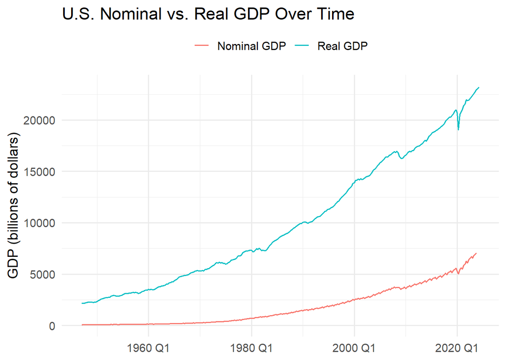

```r
ggplot(ngdp_ts, aes(x = quarter, y = gdp_billions)) +
  geom_line(aes(color = "Nominal GDP")) +
  geom_line(data = rgdp_ts, aes(color = "Real GDP")) +
  labs(
    title = "U.S. Nominal vs. Real GDP Over Time",
    x = NULL,
    y = "GDP (billions of dollars)",
    color = NULL
  ) +
  theme_minimal(base_size = 14) +
  theme(legend.position = "top")
```

**Example 2**

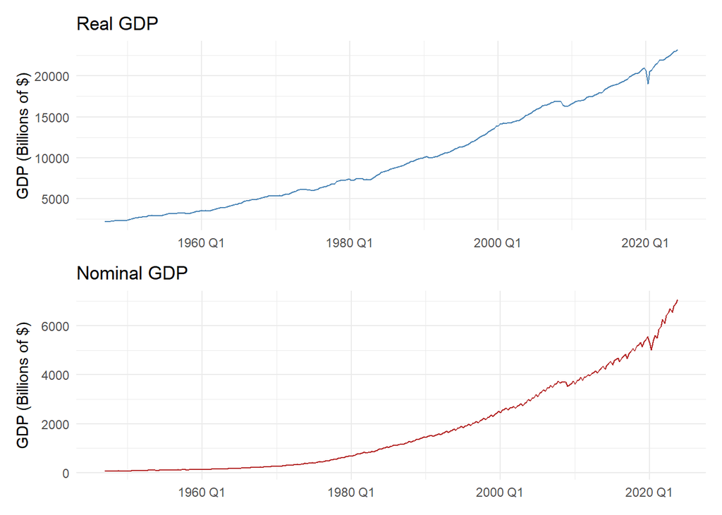

```r
# Real Plot
rplot <- autoplot(rgdp_ts, color = "steelblue") +
  labs(
    title = "Real GDP",
    y = "GDP (Billions of $)",
    x = NULL
  ) +
  theme_minimal()

# Nominal Plot
nplot <- autoplot(ngdp_ts, color = "firebrick") +
  labs(
    title = "Nominal GDP",
    y = "GDP (Billions of $)",
    x = NULL
  ) +
  theme_minimal()

# All together
rplot / nplot
```

### Question 2 - US Nominal GDP (25 points)

#### a) Please use the Holt-Winters smoothing method on the US Nominal GDP series. Show the result.

**NoteAnswer**

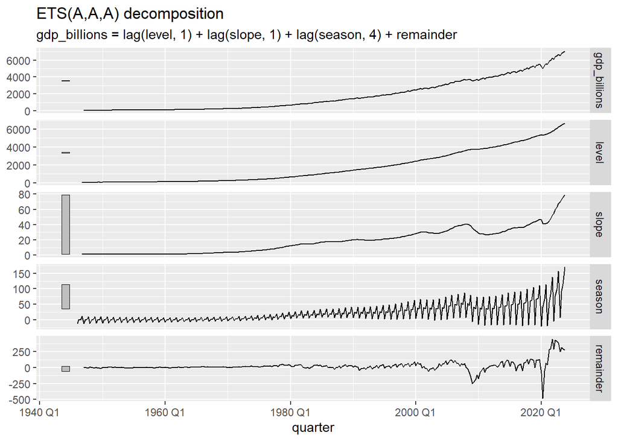

```r
ngdp_hw <- ngdp_ts |>
  model(ETS(gdp_billions ~
              trend("A", alpha = 0.15, beta = 0.01) +
              error("A") +
              season("A", gamma = 0.05),
            opt_crit = "amse",
            nmse = 1
            )
        )

autoplot(components(ngdp_hw))
```

**Clean**

```r
# Display model parameters
tidy(ngdp_hw) |> select(!.model) |> head(3) |> pander()
```

| term | estimate |
| --- | --- |
| alpha | 0.15 |
| beta | 0.01 |
| gamma | 0.05 |

```r
# Display fit statistics
glance(ngdp_hw) |> select(!.model) |> pander()
```

| sigma2 | log_lik | AIC | AICc | BIC | MSE | AMSE | MAE |
| --- | --- | --- | --- | --- | --- | --- | --- |
| 7313 | -2249 | 4509 | 4509 | 4532 | 7123 | 7123 | 42.32 |

**Decent**

```r
report(ngdp_hw)
```

```
Series: gdp_billions
Model: ETS(A,A,A)
  Smoothing parameters:
    alpha = 0.15
    beta  = 0.01
    gamma = 0.05

  Initial states:
     l[0]     b[0]     s[0]      s[-1]     s[-2]     s[-3]
 59.26695 1.288165 11.21223 0.07759504 0.8362447 -12.12607

  sigma^2:  7313.281

     AIC     AICc      BIC
4509.179 4509.458 4531.559
```

#### b) What parameters values did you choose for $\alpha$, $\beta$, and $\gamma$. Justify your choice.

**NoteAnswer**

The smoothing parameter for the level ($\alpha$) was set to **0.15**, reflecting the idea that the nominal GDP level responds relatively quickly to recent economic conditions and short-term fluctuations. In contrast, the trend ($\beta$) and seasonal ($\gamma$) smoothing parameters were set to **0.01** and **0.05** respectively, since the underlying growth rate and seasonal patterns of nominal GDP tend to evolve more gradually and are better captured by historical trends rather than immediate changes.

#### c) Please plot the Holt-Winters forecast of the series for the next 12 months superimposed against the original series. Please see [Figure 7](https://byuistats.github.io/timeseries/chapter_3_lesson_3.html#fig-crime-hw-forecast) in Chapter 3: Lesson 3.

**NoteAnswer**

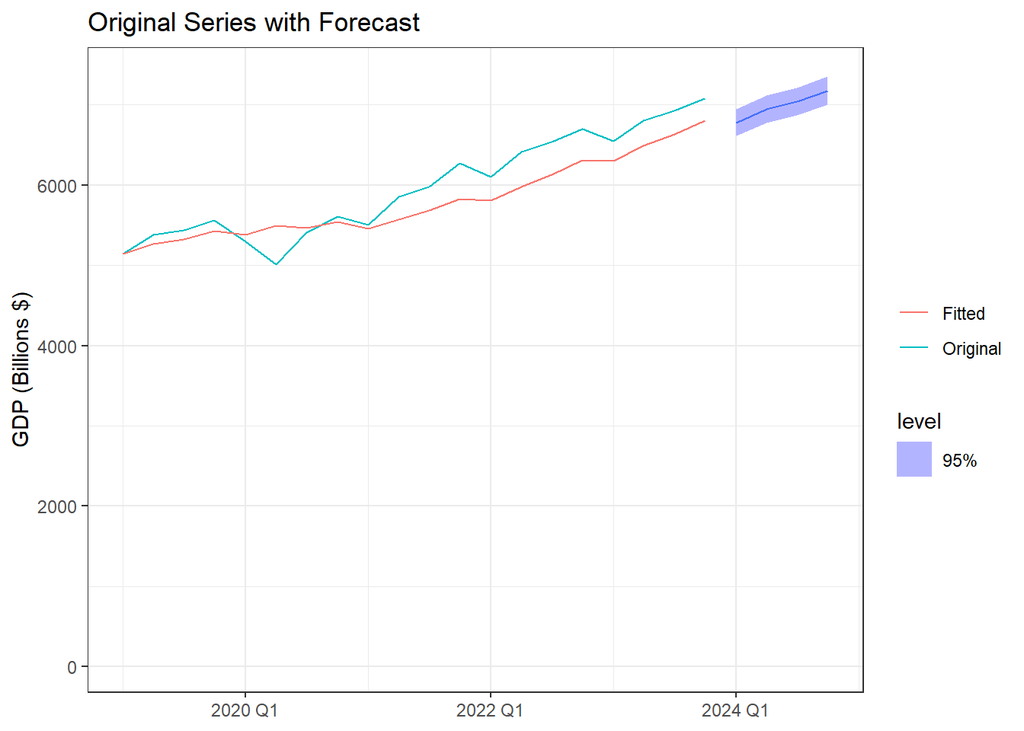

```r
ngdp_fable <- forecast(ngdp_hw, h = "1 year")

ngdp_fit <- augment(ngdp_hw)

autoplot(ngdp_fable, level = 95) + # blue line & band
  geom_line(data = ngdp_ts, aes(y = gdp_billions, color = "Original")) + # black
  geom_line(data = ngdp_fit, aes(y = .fitted, color = "Fitted")) + # orange
  scale_color_discrete(name = "") +
  scale_x_yearquarter(limits = c(as.Date("2019-01-01"), NA)) +
  labs(
    x = NULL,
    y = "GDP (Billions $)",
    color = "",
    title = "Original Series with Forecast") +
  theme_bw()
```

#### d) How confident are you in your forecast? Please explain.

**NoteAnswer**

Caution should be exercised when interpreting this forecast, as nominal GDP is susceptible to abrupt changes in economic conditions. Unexpected slowdowns or structural shifts in the economy could significantly alter both the level and trajectory of the series, limiting the model’s predictive reliability.

### Question 3 - US Real GDP (25 points)

Nominal GDP measures the market value of US output. Because market prices change over time, inflation affects the series. Real GDP is an output measure that keeps prices constant at a point in time, which eliminates the effect of inflation.

In homework 2.1 you learned about the output gap, which is a measure of business cycles. In order to estimate the output gap we need some measure of potential GDP, that is, a series that smoothes-out the cycles in the real GDP series. We can do that by choosing the smoothing parameters of the H-W algorithm to capture only the long run path of the economy. The US Congressional Budget Office calculates a series for [US Real Potential GDP](https://fred.stlouisfed.org/series/GDPPOT), please refer to it for the questions that follow.

#### a) Please use H-W to smooth the US Real GDP series to obtain an estimate of US Potential GDP.

**NoteAnswer**

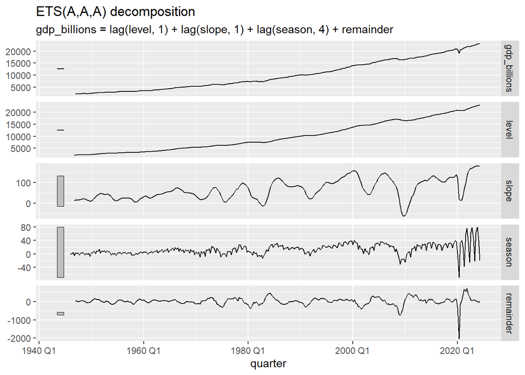

```r
# Fit Holt-Winters
rgdp_hw <- rgdp_ts |>
  model(ETS(gdp_billions ~
              trend("A", alpha = 0.2, beta = 0.05) +
              error("A") +
              season("A", gamma = 0.05),
            opt_crit = "amse",
            nmse = 1
            )
        )

autoplot(components(rgdp_hw))
```

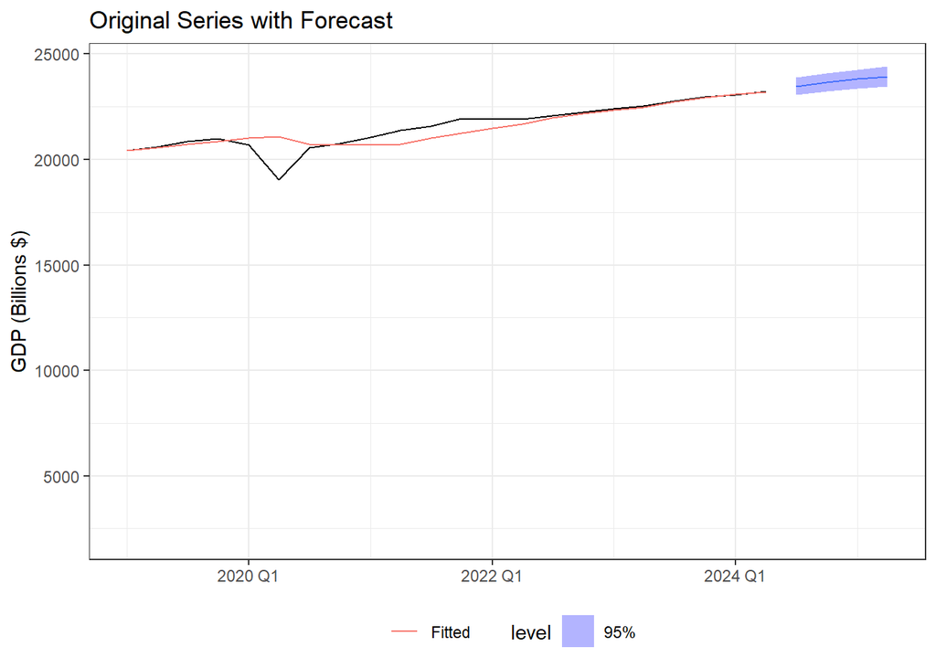

```r
# Create a forecast "fable"
#   (a tsibble for forecasts, with extra stuff like confidence intervals)
rgdp_fable <- forecast(rgdp_hw, h = "12 months")

# Create a tsibble with fitted values (.fitted) from holt winters model
rgdp_fit <- augment(rgdp_hw)

# Plot   blue line,  black line, blue band
autoplot(rgdp_fable, rgdp_ts,    level = 95) +
  geom_line(
    data = rgdp_fit,
    aes(y = .fitted, color = "Fitted") # orange line
  ) +
  scale_x_yearquarter(limits = c(as.Date("2019-01-01"), NA)) + # 2019 to end
  labs(
    x = NULL,
    y = "GDP (Billions $)",
    color = "",
    title = "Original Series with Forecast"
  ) +
  theme_bw() +
  theme(legend.position = "bottom")
```

**Clean**

```r
# Display model parameters
tidy(rgdp_hw) |> select(!.model) |> head(3) |> pander()
```

| term | estimate |
| --- | --- |
| alpha | 0.2 |
| beta | 0.05 |
| gamma | 0.05 |

```r
# Display fit statistics
glance(rgdp_hw) |> select(!.model) |> pander()
```

| sigma2 | log_lik | AIC | AICc | BIC | MSE | AMSE | MAE |
| --- | --- | --- | --- | --- | --- | --- | --- |
| 45654 | -2548 | 5108 | 5108 | 5131 | 44476 | 44476 | 131.6 |

**Decent**

```r
report(rgdp_hw)
```

```
Series: gdp_billions
Model: ETS(A,A,A)
  Smoothing parameters:
    alpha = 0.2
    beta  = 0.05
    gamma = 0.05

  Initial states:
     l[0]     b[0]      s[0]    s[-1]      s[-2]    s[-3]
 2120.792 12.87547 -4.958502 4.159639 -0.3689304 1.167792

  sigma^2:  45654.29

     AIC     AICc      BIC
5108.177 5108.454 5130.596
```

#### b) What parameters values did you choose for $\alpha$, $\beta$, and $\gamma$. Justify your choice.

**NoteAnswer**

Similar to the nominal GDP model, the smoothing parameters for real GDP were selected to balance responsiveness to recent changes with stability over time. The level parameter, $\alpha = 0.2$, was set slightly higher to give greater weight to recent observations, reflecting that real GDP tends to respond somewhat more directly to current economic conditions when adjusted for inflation. The trend parameter, $\beta = 0.05$, allows the model to moderately adjust the slope based on recent data while still maintaining a strong influence from historical growth patterns. The seasonal parameter, $\gamma = 0.05$, was kept consistent with the nominal GDP model, as the underlying seasonal patterns in real GDP are expected to remain relatively stable over time.

### Rubric

[output not shown]